# Airbnb homework_Boston

## We are here to explore the most recent trends for Airbnb accommodation in different cities. Ready, let's go!

Thanks to Airbnb Open data source: http://insideairbnb.com/get-the-data.html

[Data exploratory Questions]

1. How does the average availability of Airbnb homes vary over time in each city? Is there a clear seasonal pattern for the average nightly rate on Airbnb in the chosen city? Is there a clear weekly pattern?
2. Which neighborhood is the most expensive? Which property type is most common?
3. How does the trends compare between cities? Seattle, Boston and Beijing?

[Model prediction]

1. Can we predict the listing price? We know that price quite depends on the location, but many other factors may help predict the listing price such as room type, property type, size, #beds, any correlation between # of comments and price? E.g. Multiple regression analysis can be done in Python to put these variables together to predict the listing price of a property？

```python
# Import libraries necessary for this project
import numpy as np
import pandas as pd
#import sys

# Import plotting modules
import matplotlib.pyplot as plt
import matplotlib.dates as plotdates
import matplotlib.ticker as ticker
import seaborn as sns

pd.options.display.max_rows = 999
pd.options.display.max_columns = 999

# import libraries for price prediction
from sklearn.model_selection import train_test_split
from sklearn.metrics import r2_score
from sklearn.metrics import mean_squared_error
from sklearn.ensemble import RandomForestRegressor
#from lightgbm import LGBMRegressor

# import libraries for NLP processing - optional
#from sklearn.feature_extraction import text
#import nltk
#from nltk.tokenize import word_tokenize
#from nltk import pos_tag, bigrams, FreqDist, ne_chunk
#import detectEnglish
```

```python
# define city and read in dataset
city = 'boston'
calendar = pd.read_csv( city + '/calendar.csv.gz')
listing = pd.read_csv(city + '/listings.csv.gz')
review =pd.read_csv(city + '/reviews.csv.gz')
```

```python
print('We have', calendar.date.nunique(), 'days and', calendar.listing_id.nunique(), 'unique listings in the ' + city+ ' calendar data.')
print('We have', listing.id.nunique(), 'listings in the ' + city+ '  listing data.')
print('We have', review.shape[0], 'reviews for', review.listing_id.nunique(),'listings in the ' + city+ ' review data')
```

```
We have 366 days and 6264 unique listings in the boston calendar data.
We have 6264 listings in the boston  listing data.
We have 225880 reviews for 5088 listings in the boston review data
```

```python
#listing.head()
#review.head()
#calendar.head()
#listings_seattle.iloc[1000:1200,]
#calendar.info()
#calendar.dtypes
```

```python
print("Listing dataset has %2d records and %2d columns" %(listing.shape[0],listing.shape[1]))
print("Calendar dataset has %2d records and %2d columns" %(calendar.shape[0],calendar.shape[1]))
print("Review dataset has %2d records and %2d columns" %(review.shape[0],review.shape[1]))
```

```
Listing dataset has 6264 records and 106 columns
Calendar dataset has 2286360 records and  7 columns
Review dataset has 225880 records and  6 columns
```

### Prepare Calendar Data Set to Answer Question 1

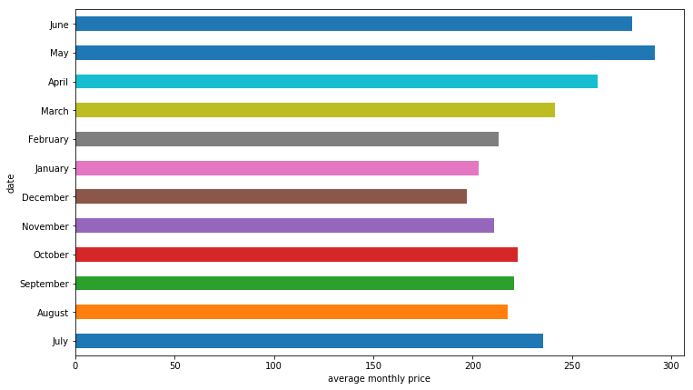

```python
#changing data type for price and date
calendar['price'] = calendar['price'].str.replace(',', '')
calendar['price'] = calendar['price'].str.replace('$', '')
calendar['price'] = calendar['price'].astype(float)

calendar['date'] = pd.to_datetime(calendar['date'])
mean_of_month = calendar.groupby(calendar['date'].dt.strftime('%B'),
                                 sort=False)['price'].mean()
mean_of_month.plot(kind = 'barh' , figsize = (12,7))
plt.xlabel('average monthly price');
```

#### Q: Is there a clear seasonal pattern for the average nightly rate on Airbnb in the chosen city? Is there a clear weekly pattern?

A: In Boston, April-June seems to be the most popular month as the average monthly price is higher

```python
# calendar.isnull().sum()
# calendar.info()
```

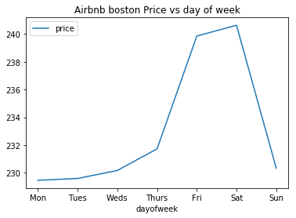

```python
calendar['dayofweek'] = calendar.date.dt.weekday_name
cats = [ 'Monday', 'Tuesday', 'Wednesday', 'Thursday', 'Friday', 'Saturday', 'Sunday']
price_week=calendar[['dayofweek','price']]
price_week = price_week.groupby(['dayofweek']).mean().reindex(cats)
#price_week.drop(['listing_id', 'minimum_nights','maximum_nights'] ,axis=1, inplace=True)
price_week.plot()
ticks = list(range(0, 7, 1)) # points on the x axis where you want the label to appear
labels = "Mon Tues Weds Thurs Fri Sat Sun".split()
plt.title('Airbnb '+ city + ' Price vs day of week')
plt.xticks(ticks, labels);
```

```python
print(price_week.iloc[0:10,].round(2))
# price_week.groupby(['dayofweek'])['price'].describe()
```

```
            price
dayofweek
Monday     229.46
Tuesday    229.60
Wednesday  230.17
Thursday   231.73
Friday     239.85
Saturday   240.63
Sunday     230.33
```

[output not shown]

#### Q: Is there a clear weekly pattern on the price?

A：Yes. Weekend Rate is generally 5% higher than that in the weekdays.

#### Q: How does the average availability of Airbnb homes vary over time in each city?

Find out daily average availability for the time period. Convert available column to 0 if available and 1 if not.

```python
calendar.available.value_counts()
#f (false) means not available, t(true) means available.
```

```
f    1472469
t     813891
Name: available, dtype: int64
```

```python
# calendar['maximum_nights'].value_counts()
```

```python
calendar.date.min(), calendar.date.max()
```

```
(Timestamp('2019-07-14 00:00:00'), Timestamp('2020-07-13 00:00:00'))
```

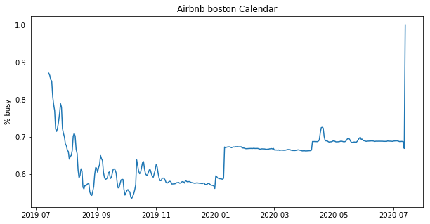

```python
# Find out daily average availability for the time period. Convert available column to 0 if available and 1 if not.
calendar_new = calendar[['date', 'available']]
calendar_new['busy'] = calendar_new.available.map( lambda x: 0 if x == 't' else 1)
calendar_new = calendar_new.groupby('date')['busy'].mean().reset_index()
calendar_new['date'] = pd.to_datetime(calendar_new['date'])
plt.figure(figsize=(10, 5))
plt.plot(calendar_new['date'], calendar_new['busy'])
plt.title('Airbnb '+ city + ' Calendar')
plt.ylabel('% busy')
plt.show();
```

#### Q: How does the average availability of Airbnb homes vary over time in each city?

```python
#calendar.drop_duplicates()
#calendar.drop_duplicates(keep='first', inplace=True)
#calendar.info()
```

### Prepare Listing Data Set to Answer Question 2

```python
#checking for missing values in the listing data frame
def identify_null_col(dataframe):
    """Identify columns that have missing data in the dataframe
    Args:
        dataframe: input dataframe to identify missing data
    Returns:
        dataframe: dataframe of column names as index, # missing records, % missing records
    """
    null_col = dataframe.columns[dataframe.isna().sum()>0]
    col_null_val = dataframe[null_col].isna().sum().sort_values(ascending=False)
    per_null_val = (dataframe[null_col].isna().sum()/dataframe.shape[0]*100).sort_values(ascending=False)
    nulls_df = pd.DataFrame(col_null_val,columns=['#Nulls'])
    nulls_df['%Nulls']=per_null_val
    print('Number of columns with missing data:',nulls_df.shape[0])
    return nulls_df
identify_null_col(listing)
```

```
Number of columns with missing data: 51
```

|  | #Nulls | %Nulls |
| --- | --- | --- |
| xl_picture_url | 6264 | 100.000000 |
| neighbourhood_group_cleansed | 6264 | 100.000000 |
| medium_url | 6264 | 100.000000 |
| host_acceptance_rate | 6264 | 100.000000 |
| thumbnail_url | 6264 | 100.000000 |
| license | 6252 | 99.808429 |
| square_feet | 6134 | 97.924649 |
| monthly_price | 5804 | 92.656450 |
| weekly_price | 5784 | 92.337165 |
| access | 2541 | 40.565134 |
| notes | 2505 | 39.990421 |
| interaction | 2294 | 36.621967 |
| transit | 2204 | 35.185185 |
| host_about | 2145 | 34.243295 |
| house_rules | 1999 | 31.912516 |
| neighborhood_overview | 1989 | 31.752874 |
| security_deposit | 1738 | 27.745849 |
| space | 1651 | 26.356960 |
| review_scores_checkin | 1236 | 19.731801 |
| review_scores_location | 1236 | 19.731801 |
| review_scores_value | 1236 | 19.731801 |
| review_scores_accuracy | 1234 | 19.699872 |
| review_scores_cleanliness | 1232 | 19.667944 |
| review_scores_rating | 1231 | 19.651980 |
| review_scores_communication | 1231 | 19.651980 |
| reviews_per_month | 1175 | 18.757982 |
| first_review | 1175 | 18.757982 |
| last_review | 1175 | 18.757982 |
| host_response_rate | 1090 | 17.401022 |
| host_response_time | 1090 | 17.401022 |
| cleaning_fee | 966 | 15.421456 |
| host_neighbourhood | 531 | 8.477011 |
| summary | 139 | 2.219029 |
| description | 65 | 1.037676 |
| zipcode | 32 | 0.510856 |
| host_location | 20 | 0.319285 |
| market | 9 | 0.143678 |
| city | 8 | 0.127714 |
| jurisdiction_names | 7 | 0.111750 |
| host_total_listings_count | 5 | 0.079821 |
| host_name | 5 | 0.079821 |
| host_since | 5 | 0.079821 |
| host_is_superhost | 5 | 0.079821 |
| host_thumbnail_url | 5 | 0.079821 |
| host_picture_url | 5 | 0.079821 |
| host_listings_count | 5 | 0.079821 |
| host_has_profile_pic | 5 | 0.079821 |
| host_identity_verified | 5 | 0.079821 |
| bathrooms | 3 | 0.047893 |
| bedrooms | 2 | 0.031928 |
| name | 1 | 0.015964 |

```python
#listing.groupby(by='neighbourhood_cleansed').count()[['id']].sort_values(by='id', ascending=False).head(10)
```

```python
listing.review_scores_rating.describe()
```

```
count    5033.000000
mean       93.028611
std         8.607613
min        20.000000
25%        90.000000
50%        95.000000
75%        99.000000
max       100.000000
Name: review_scores_rating, dtype: float64
```

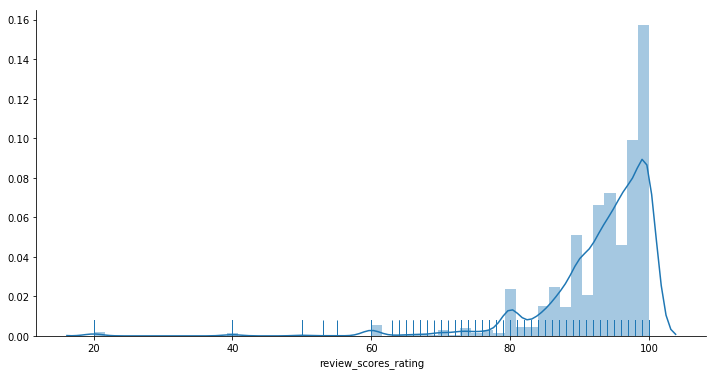

```python
#understand distribution of review rating
plt.figure(figsize=(12,6))
sns.distplot(listing.review_scores_rating.dropna(), rug=True)
sns.despine()
plt.show();
```

```python
#convert price info to float type
listing['price'] = listing['price'].str.replace(',', '')
listing['price'] = listing['price'].str.replace('$', '')
listing['price'] = listing['price'].astype(float)
listing['price'].describe()
```

```
count     6264.000000
mean       199.063697
std        347.696661
min          0.000000
25%         80.000000
50%        149.000000
75%        235.000000
max      10000.000000
Name: price, dtype: float64
```

```python
listing.iloc[np.argmax(listing['price'])]
```

```
id                                                                                       35156022
listing_url                                                 https://www.airbnb.com/rooms/35156022
scrape_id                                                                          20190714024644
last_scraped                                                                           2019-07-14
name                                                                                         TEST
summary                                         This luxury apartment is spacious with tons of...
space                                                                                         NaN
description                                     This luxury apartment is spacious with tons of...
experiences_offered                                                                          none
neighborhood_overview                                                                         NaN
notes                                                                                         NaN
transit                                                                                       NaN
access                                                                                        NaN
interaction                                                                                   NaN
house_rules                                                         Please no shoes in the house.
thumbnail_url                                                                                 NaN
medium_url                                                                                    NaN
picture_url                                     https://a0.muscache.com/im/pictures/78db1afe-f...
xl_picture_url                                                                                NaN
host_id                                                                                 263931404
host_url                                              https://www.airbnb.com/users/show/263931404
host_name                                                                                    Amoi
host_since                                                                             2019-05-24
host_location                                                                                  CA
host_about                                                                                    NaN
host_response_time                                                                            NaN
host_response_rate                                                                            NaN
host_acceptance_rate                                                                          NaN
host_is_superhost                                                                               f
host_thumbnail_url                              https://a0.muscache.com/im/pictures/user/a5b27...
host_picture_url                                https://a0.muscache.com/im/pictures/user/a5b27...
host_neighbourhood                                                                      South End
host_listings_count                                                                             1
host_total_listings_count                                                                       1
host_verifications                                                             ['email', 'phone']
host_has_profile_pic                                                                            t
host_identity_verified                                                                          f
street                                                                  Boston, MA, United States
neighbourhood                                                                           South End
neighbourhood_cleansed                                                                  South End
```

[output cut: 52 more lines]

```
review_scores_value                                                                           NaN
requires_license                                                                                f
license                                                                                       NaN
jurisdiction_names                                 {"Massachusetts State"," Massachusetts State"}
instant_bookable                                                                                t
is_business_travel_ready                                                                        f
cancellation_policy                                                                      moderate
require_guest_profile_picture                                                                   f
require_guest_phone_verification                                                                f
calculated_host_listings_count                                                                  1
calculated_host_listings_count_entire_homes                                                     1
calculated_host_listings_count_private_rooms                                                    0
calculated_host_listings_count_shared_rooms                                                     0
reviews_per_month                                                                             NaN
Name: 5876, dtype: object
```

```python
listing.iloc[np.argmax(listing['price'])]['neighbourhood_cleansed']
```

```
'South End'
```

```
cutoff is 1242.15
```

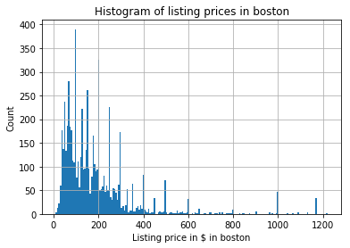

```python
outlier = listing.price.mean()+ 3*listing.price.std()
print ('cutoff is {:.2f}'.format(outlier))
#print ('cutoff is %.2f %.4f' % (outlier, outlier))

listing.loc[(listing.price <= outlier)  & (listing.price > 0)].price.hist(bins=200)
plt.ylabel('Count')
plt.xlabel('Listing price in $ in ' + city)
plt.title('Histogram of listing prices in ' + city);
```

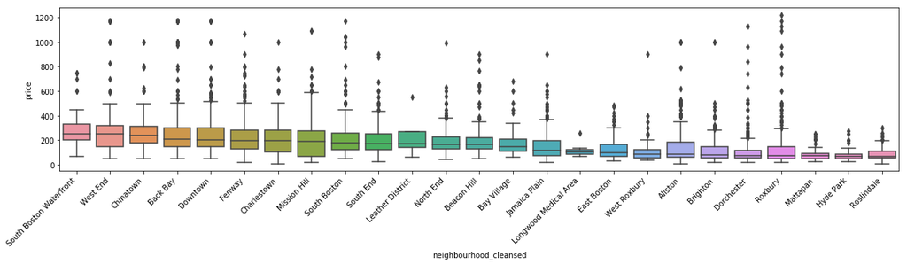

```python
sort_price = listing.loc[(listing.price <= outlier) & (listing.price > 0)].groupby('neighbourhood_cleansed')['price'].median()\
            .sort_values(ascending=False).index
plt.figure(figsize = (20,4))
sns.boxplot(y='price', x='neighbourhood_cleansed', data=listing.loc[(listing.price <= outlier) & (listing.price > 0)],
            order=sort_price)
ax = plt.gca()
ax.set_xticklabels(ax.get_xticklabels(), rotation=45, ha='right')
plt.show();
```

```python
listing.loc[(listing.price <= outlier) & (listing.price > 0)].groupby('neighbourhood_cleansed')['price']\
        .describe().sort_values('count',ascending=False)
```

| neighbourhood_cleansed | count | mean | std | min | 25% | 50% | 75% | max |
| --- | --- | --- | --- | --- | --- | --- | --- | --- |
| Dorchester | 579.0 | 108.335060 | 120.794293 | 19.0 | 55.00 | 75.0 | 120.00 | 1130.0 |
| Downtown | 497.0 | 260.885312 | 189.191896 | 50.0 | 149.00 | 200.0 | 299.00 | 1171.0 |
| Jamaica Plain | 487.0 | 148.174538 | 106.250521 | 21.0 | 75.00 | 120.0 | 194.50 | 900.0 |
| Back Bay | 446.0 | 297.639013 | 257.992600 | 50.0 | 150.00 | 209.0 | 300.00 | 1171.0 |
| South End | 401.0 | 196.581047 | 106.505465 | 25.0 | 125.00 | 175.0 | 249.00 | 900.0 |
| Fenway | 398.0 | 229.243719 | 149.204772 | 20.0 | 132.25 | 199.0 | 283.25 | 1064.0 |
| Roxbury | 376.0 | 130.795213 | 162.769114 | 20.0 | 49.00 | 75.0 | 149.00 | 1220.0 |
| Brighton | 370.0 | 113.340541 | 100.938108 | 22.0 | 55.00 | 80.0 | 148.50 | 1000.0 |
| East Boston | 349.0 | 125.323782 | 76.432985 | 30.0 | 69.00 | 100.0 | 169.00 | 485.0 |
| Allston | 343.0 | 156.839650 | 170.959112 | 10.0 | 64.50 | 86.0 | 185.00 | 1000.0 |
| South Boston | 326.0 | 220.837423 | 162.768702 | 48.0 | 122.75 | 178.0 | 259.25 | 1170.0 |
| Beacon Hill | 257.0 | 194.482490 | 119.658207 | 50.0 | 130.00 | 168.0 | 220.00 | 900.0 |
| North End | 241.0 | 194.655602 | 107.133375 | 41.0 | 129.00 | 169.0 | 229.00 | 995.0 |
| Mission Hill | 221.0 | 192.298643 | 165.610939 | 18.0 | 70.00 | 189.0 | 279.00 | 1090.0 |
| Charlestown | 159.0 | 220.081761 | 156.816872 | 10.0 | 103.00 | 195.0 | 284.50 | 1000.0 |
| Chinatown | 145.0 | 270.531034 | 172.910705 | 50.0 | 179.00 | 238.0 | 312.00 | 999.0 |
| West End | 145.0 | 335.668966 | 296.601843 | 49.0 | 150.00 | 249.0 | 319.00 | 1171.0 |
| South Boston Waterfront | 118.0 | 287.161017 | 128.578884 | 70.0 | 203.00 | 250.0 | 330.00 | 750.0 |
| Roslindale | 116.0 | 91.008621 | 53.789525 | 10.0 | 54.00 | 70.0 | 111.25 | 300.0 |
| West Roxbury | 81.0 | 116.222222 | 112.959285 | 35.0 | 58.00 | 89.0 | 125.00 | 900.0 |
| Hyde Park | 63.0 | 80.428571 | 49.448153 | 25.0 | 50.00 | 71.0 | 85.00 | 275.0 |
| Mattapan | 63.0 | 85.492063 | 52.904013 | 28.0 | 52.00 | 72.0 | 95.50 | 250.0 |
| Bay Village | 48.0 | 193.958333 | 135.156955 | 65.0 | 109.00 | 150.0 | 209.75 | 680.0 |
| Longwood Medical Area | 11.0 | 116.181818 | 50.207207 | 69.0 | 87.00 | 105.0 | 122.00 | 255.0 |
| Leather District | 4.0 | 241.000000 | 212.400565 | 65.0 | 143.75 | 174.5 | 271.75 | 550.0 |

### Q: Which neighborhood is the most expensive and which neighbourhood has most units?

A: South Boston Waterfront has the highest median price as that is one of the best scene in Boston with waterfront views, but the room listing are quite limited, so Dorchester and Downtown area are other good choices with higher room listings.

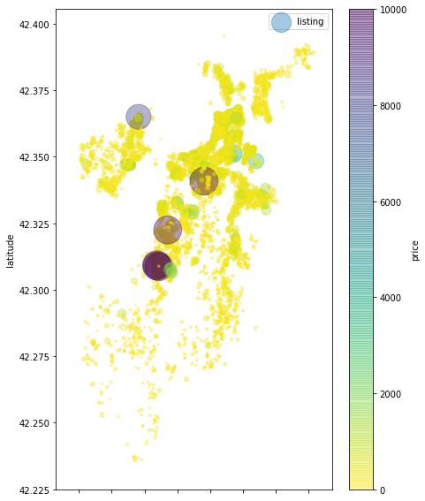

```python
# Price based on geographical data
listing.plot(kind='scatter', x='longitude', y='latitude', alpha=0.4
             ,s=listing['price']/10
             , label = 'listing'
            , c = 'price', figsize =(7,10)
            , cmap = plt.get_cmap("viridis_r")
            , colorbar=True);

plt.legend();
```

```python
#inspect and understand more of listing data
unique_host = listing['host_id'].unique()
'Number of unique hosts in listing dataset:', len(unique_host)
# %Superhosts in the dataset
listing['host_is_superhost'].value_counts()/listing.shape[0]*100
```

```
f    76.803959
t    23.116220
Name: host_is_superhost, dtype: float64
```

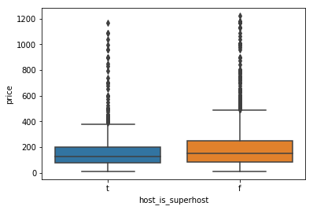

```python
sns.boxplot(y='price', x='host_is_superhost', data=listing.loc[(listing.price <= outlier) & (listing.price > 0)])
plt.show();
```

```python
listing.loc[(listing.price <= outlier) & (listing.price > 0)].groupby('host_is_superhost')['price'].describe()
```

| host_is_superhost | count | mean | std | min | 25% | 50% | 75% | max |
| --- | --- | --- | --- | --- | --- | --- | --- | --- |
| f | 4792.0 | 194.587855 | 175.908178 | 10.0 | 85.0 | 150.0 | 248.0 | 1220.0 |
| t | 1447.0 | 161.100207 | 129.821637 | 10.0 | 75.0 | 125.0 | 200.0 | 1170.0 |

##### for Boston, being a superhost does not seem to grant a better price for the house.. a little bit counter-intuititve...

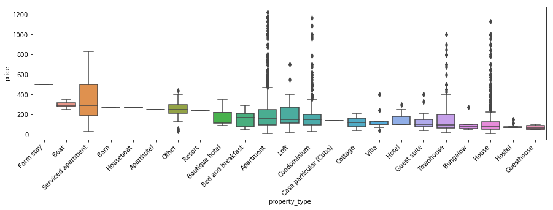

```python
plt.figure(figsize = (15,4))
sort_price = listing.loc[(listing.price <= outlier) & (listing.price > 0)].groupby('property_type')['price'].median()\
                    .sort_values(ascending=False).index
sns.boxplot(y='price', x='property_type', data=listing.loc[(listing.price <= outlier) & (listing.price > 0)], order=sort_price)
ax = plt.gca()
ax.set_xticklabels(ax.get_xticklabels(), rotation=45, ha='right')
plt.show();
```

```python
listing.loc[(listing.price <= outlier) & (listing.price > 0)].property_type.value_counts().sort_values(ascending = False)

listing.loc[(listing.price <= outlier) & (listing.price > 0)].groupby('property_type')['price'].describe().sort_values('count',ascending = False)
#listing.loc[(listing.price <= outlier) & (listing.price > 0)]['price'].median()
```

| property_type | count | mean | std | min | 25% | 50% | 75% | max |
| --- | --- | --- | --- | --- | --- | --- | --- | --- |
| Apartment | 4137.0 | 199.859318 | 174.826168 | 10.0 | 99.00 | 159.0 | 249.00 | 1220.0 |
| House | 942.0 | 124.220807 | 136.471031 | 10.0 | 56.00 | 75.0 | 125.00 | 1130.0 |
| Condominium | 585.0 | 176.105983 | 135.779380 | 26.0 | 97.00 | 150.0 | 200.00 | 1170.0 |
| Townhouse | 153.0 | 173.228758 | 183.659027 | 15.0 | 65.00 | 99.0 | 200.00 | 999.0 |
| Serviced apartment | 126.0 | 329.476190 | 178.945923 | 31.0 | 189.00 | 294.0 | 499.00 | 829.0 |
| Guest suite | 83.0 | 119.686747 | 56.709342 | 40.0 | 80.00 | 100.0 | 150.00 | 400.0 |
| Loft | 56.0 | 198.375000 | 123.082465 | 25.0 | 117.25 | 150.0 | 275.00 | 700.0 |
| Other | 49.0 | 251.265306 | 76.929832 | 37.0 | 213.00 | 250.0 | 298.00 | 439.0 |
| Bed and breakfast | 46.0 | 153.130435 | 75.652894 | 50.0 | 76.25 | 170.0 | 209.75 | 289.0 |
| Hotel | 13.0 | 145.923077 | 68.244000 | 100.0 | 100.00 | 100.0 | 179.00 | 300.0 |
| Hostel | 10.0 | 83.800000 | 27.038245 | 70.0 | 70.00 | 71.5 | 75.00 | 150.0 |
| Villa | 9.0 | 146.111111 | 110.786331 | 40.0 | 100.00 | 100.0 | 130.00 | 400.0 |
| Boutique hotel | 9.0 | 204.666667 | 87.196617 | 90.0 | 113.00 | 219.0 | 220.00 | 350.0 |
| Guesthouse | 6.0 | 71.666667 | 25.033311 | 50.0 | 50.00 | 65.0 | 91.25 | 105.0 |
| Boat | 6.0 | 298.333333 | 35.590261 | 250.0 | 278.75 | 295.0 | 318.75 | 350.0 |
| Bungalow | 5.0 | 113.400000 | 92.400216 | 50.0 | 60.00 | 82.0 | 100.00 | 275.0 |
| Cottage | 2.0 | 123.500000 | 120.915260 | 38.0 | 80.75 | 123.5 | 166.25 | 209.0 |
| Houseboat | 2.0 | 270.000000 | 7.071068 | 265.0 | 267.50 | 270.0 | 272.50 | 275.0 |
| Farm stay | 1.0 | 500.000000 | NaN | 500.0 | 500.00 | 500.0 | 500.00 | 500.0 |
| Casa particular (Cuba) | 1.0 | 140.000000 | NaN | 140.0 | 140.00 | 140.0 | 140.00 | 140.0 |
| Resort | 1.0 | 245.000000 | NaN | 245.0 | 245.00 | 245.0 | 245.00 | 245.0 |
| Barn | 1.0 | 275.000000 | NaN | 275.0 | 275.00 | 275.0 | 275.00 | 275.0 |
| Aparthotel | 1.0 | 250.000000 | NaN | 250.0 | 250.00 | 250.0 | 250.00 | 250.0 |

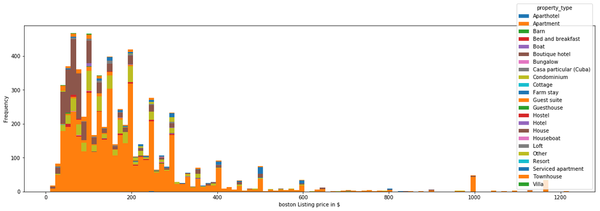

```python
listing.loc[(listing.price <= outlier) & (listing.price > 0)].pivot(columns = 'property_type', values = 'price')\
        .plot.hist(stacked = True, bins=100, figsize = (20,6))

plt.xlabel(city + ' Listing price in $');
```

#### Q: Which property type is most common?

A: In Boston, more than half of the lsitings are apartment type, given it's a city with higher population as compared to Seattle. So apartment is a practical type of property for renting.

#### Other Data Exploration for Listing

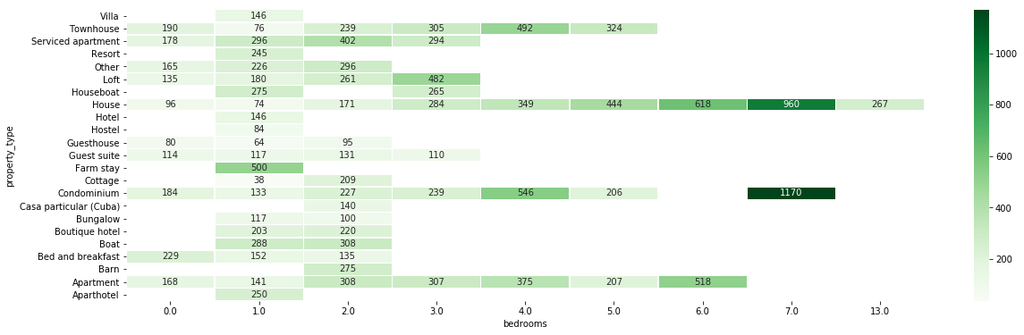

```python
plt.figure(figsize = (20,6))
sns.heatmap(listing.loc[(listing.price <= outlier) & (listing.price > 0)]\
                .groupby(['property_type', 'bedrooms'])\
                .mean()['price']\
                .reset_index()\
                .pivot('property_type', 'bedrooms', 'price')\
                .sort_index(ascending=False),
            cmap="Greens", fmt='.0f', annot=True, linewidths=0.5)
plt.show();
```

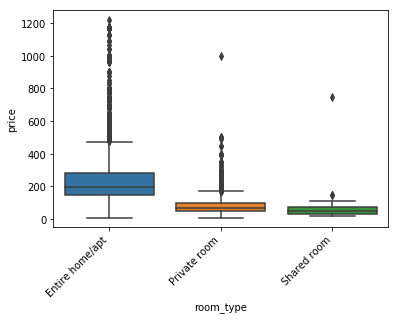

```python
sort_price = listing.loc[(listing.price <= outlier) & (listing.price > 0)].groupby('room_type')['price'].median()\
                    .sort_values(ascending=False).index
sns.boxplot(y='price', x='room_type', data=listing.loc[(listing.price <= outlier) & (listing.price > 0)], order=sort_price)
ax = plt.gca()
ax.set_xticklabels(ax.get_xticklabels(), rotation=45, ha='right')
plt.show();
```

### Modelling Listing Price

#### Data preprocessing and feature engineering

#### Handle categorical and missing data for Listing.csv

```python
'''listing.amenities = listing.amenities.str.replace("[{}]", "").str.replace('"', "")
from sklearn.feature_extraction.text import CountVectorizer
count_vectorizer =  CountVectorizer(tokenizer=lambda x: x.split(','))
amenities = count_vectorizer.fit_transform(listing['amenities'])
df_amenities = pd.DataFrame(amenities.toarray(), columns=count_vectorizer.get_feature_names())
df_amenities = df_amenities.drop('',1)'''
```

```
'listing.amenities = listing.amenities.str.replace("[{}]", "").str.replace(\'"\', "")\nfrom sklearn.feature_extraction.text import CountVectorizer\ncount_vectorizer =  CountVectorizer(tokenizer=lambda x: x.split(\',\'))\namenities = count_vectorizer.fit_transform(listing[\'amenities\'])\ndf_amenitie…
```

```python
# convert binary column into interger format
columns =  ['host_is_superhost',  'instant_bookable']

for c in columns:
    listing[c] = listing[c].replace('f',0,regex=True)
    listing[c] = listing[c].replace('t',1,regex=True)
```

```python
# fill NA
listing['security_deposit'] = listing['security_deposit'].fillna(value=0)
listing['security_deposit'] = listing['security_deposit'].replace( '[\$,)]','', regex=True ).astype(float)
listing['cleaning_fee'] = listing['cleaning_fee'].fillna(value=0)
listing['cleaning_fee'] = listing['cleaning_fee'].replace( '[\$,)]','', regex=True ).astype(float)
```

```python
#listing['zipcode'] = listing['zipcode'].str.replace('98104-4417','98104').astype(float)
```

```python
listing_new = listing[['host_is_superhost', 'host_total_listings_count', 'bedrooms', 'number_of_reviews','review_scores_rating',
                       'neighbourhood_cleansed','room_type','property_type','accommodates','price']]
```

```python
sorted(listing.columns.tolist())
sorted(listing_new.columns.tolist())
#listing_new.info()
```

```
['accommodates',
 'bedrooms',
 'host_is_superhost',
 'host_total_listings_count',
 'neighbourhood_cleansed',
 'number_of_reviews',
 'price',
 'property_type',
 'review_scores_rating',
 'room_type']
```

```python
corr = listing_new.loc[(listing_new.price <= outlier) & (listing_new.price > 0)].dropna().corr()
```

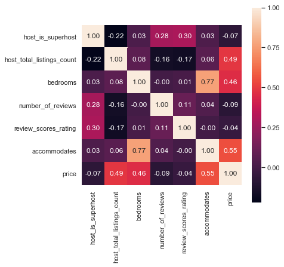

```python
plt.figure(figsize = (6,6))
sns.set(font_scale=1)
sns.heatmap(corr, cbar = True, annot=True, square = True, fmt = '.2f')
plt.show();
```

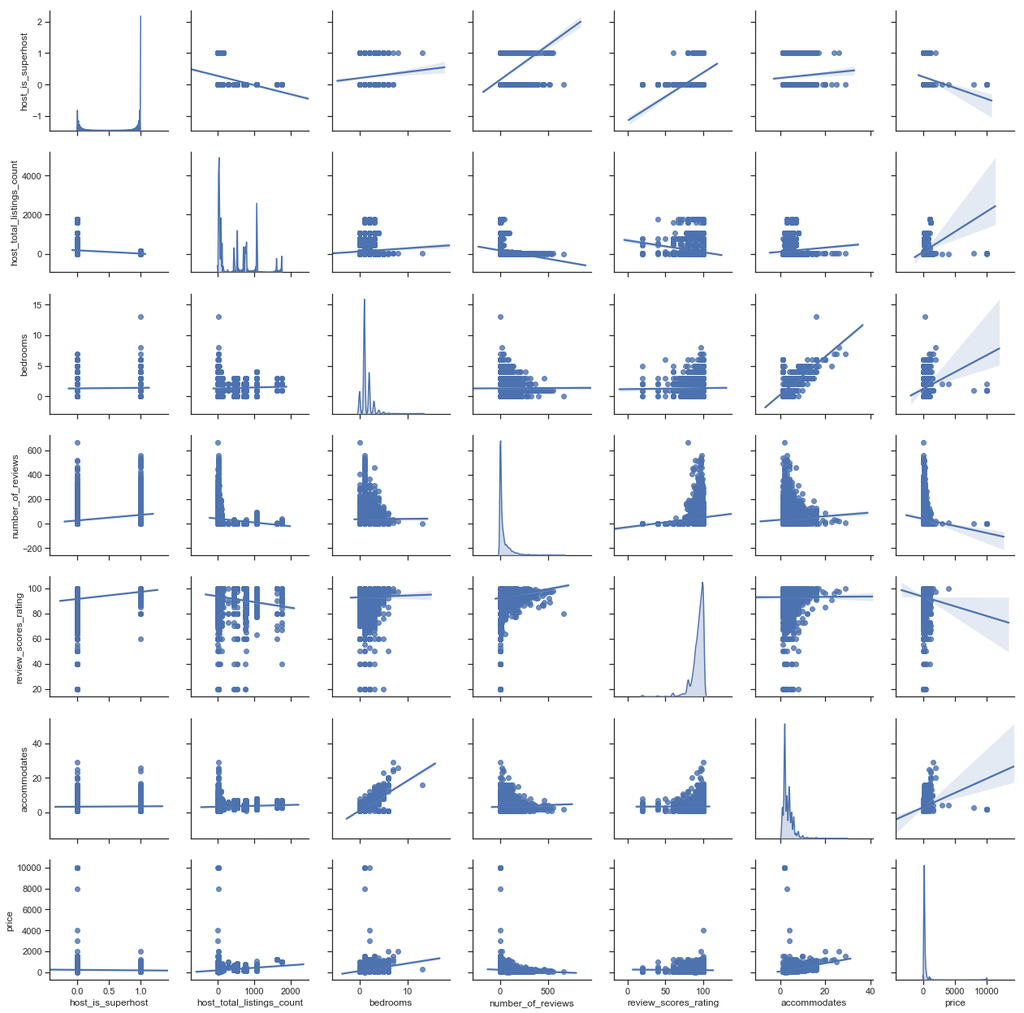

```python
sns.set(style="ticks", color_codes=True)
g = sns.pairplot(listing_new,diag_kind='kde',palette="husl", kind='reg')
```

```python
for col in listing_new.columns[listing_new.isnull().any()]:
    print('Filling NA for column {}'.format(col))
    listing_new[col] = listing_new[col].fillna(listing_new[col].median())
```

```
Filling NA for column host_is_superhost
Filling NA for column host_total_listings_count
Filling NA for column bedrooms
Filling NA for column review_scores_rating
```

```python
listing_new = pd.get_dummies(listing_new, columns = ['property_type', 'room_type','neighbourhood_cleansed'], drop_first=True)
```

```python
#listing_new = pd.concat([listing_new, df_amenities], axis=1, join='inner')
```

```python
sorted(listing_new.columns.tolist())
```

```
['accommodates',
 'bedrooms',
 'host_is_superhost',
 'host_total_listings_count',
 'neighbourhood_cleansed_Back Bay',
 'neighbourhood_cleansed_Bay Village',
 'neighbourhood_cleansed_Beacon Hill',
 'neighbourhood_cleansed_Brighton',
 'neighbourhood_cleansed_Charlestown',
 'neighbourhood_cleansed_Chinatown',
 'neighbourhood_cleansed_Dorchester',
 'neighbourhood_cleansed_Downtown',
 'neighbourhood_cleansed_East Boston',
 'neighbourhood_cleansed_Fenway',
 'neighbourhood_cleansed_Hyde Park',
 'neighbourhood_cleansed_Jamaica Plain',
 'neighbourhood_cleansed_Leather District',
 'neighbourhood_cleansed_Longwood Medical Area',
 'neighbourhood_cleansed_Mattapan',
 'neighbourhood_cleansed_Mission Hill',
 'neighbourhood_cleansed_North End',
 'neighbourhood_cleansed_Roslindale',
 'neighbourhood_cleansed_Roxbury',
 'neighbourhood_cleansed_South Boston',
 'neighbourhood_cleansed_South Boston Waterfront',
 'neighbourhood_cleansed_South End',
 'neighbourhood_cleansed_West End',
 'neighbourhood_cleansed_West Roxbury',
 'number_of_reviews',
 'price',
 'property_type_Apartment',
 'property_type_Barn',
 'property_type_Bed and breakfast',
 'property_type_Boat',
 'property_type_Boutique hotel',
 'property_type_Bungalow',
 'property_type_Casa particular (Cuba)',
 'property_type_Condominium',
 'property_type_Cottage',
 'property_type_Farm stay',
 'property_type_Guest suite',
 'property_type_Guesthouse',
 'property_type_Hostel',
 'property_type_Hotel',
 'property_type_House',
 'property_type_Houseboat',
 'property_type_Loft',
 'property_type_Other',
 'property_type_Resort',
 'property_type_Serviced apartment',
 'property_type_Townhouse',
 'property_type_Villa',
 'review_scores_rating',
 'room_type_Private room',
 'room_type_Shared room']
```

```python
listing_new.head()
```

|  | host_is_superhost | host_total_listings_count | bedrooms | number_of_reviews | review_scores_rating | accommodates | price | property_type_Apartment | property_type_Barn | property_type_Bed and breakfast | property_type_Boat | property_type_Boutique hotel | property_type_Bungalow | property_type_Casa particular (Cuba) | property_type_Condominium | property_type_Cottage | property_type_Farm stay | property_type_Guest suite | property_type_Guesthouse | property_type_Hostel | property_type_Hotel | property_type_House | property_type_Houseboat | property_type_Loft | property_type_Other | property_type_Resort | property_type_Serviced apartment | property_type_Townhouse | property_type_Villa | … |
| --- | --- | --- | --- | --- | --- | --- | --- | --- | --- | --- | --- | --- | --- | --- | --- | --- | --- | --- | --- | --- | --- | --- | --- | --- | --- | --- | --- | --- | --- | --- |
| 0 | 1.0 | 4.0 | 1.0 | 15 | 99.0 | 2 | 125.0 | 1 | 0 | 0 | 0 | 0 | 0 | 0 | 0 | 0 | 0 | 0 | 0 | 0 | 0 | 0 | 0 | 0 | 0 | 0 | 0 | 0 | 0 | … |
| 1 | 0.0 | 6.0 | 1.0 | 95 | 95.0 | 2 | 145.0 | 0 | 0 | 0 | 0 | 0 | 0 | 0 | 0 | 0 | 0 | 1 | 0 | 0 | 0 | 0 | 0 | 0 | 0 | 0 | 0 | 0 | 0 | … |
| 2 | 0.0 | 6.0 | 1.0 | 102 | 96.0 | 4 | 169.0 | 0 | 0 | 0 | 0 | 0 | 0 | 0 | 1 | 0 | 0 | 0 | 0 | 0 | 0 | 0 | 0 | 0 | 0 | 0 | 0 | 0 | 0 | … |
| 3 | 1.0 | 1.0 | 1.0 | 80 | 98.0 | 2 | 65.0 | 1 | 0 | 0 | 0 | 0 | 0 | 0 | 0 | 0 | 0 | 0 | 0 | 0 | 0 | 0 | 0 | 0 | 0 | 0 | 0 | 0 | 0 | … |
| 4 | 0.0 | 12.0 | 1.0 | 23 | 92.0 | 2 | 99.0 | 1 | 0 | 0 | 0 | 0 | 0 | 0 | 0 | 0 | 0 | 0 | 0 | 0 | 0 | 0 | 0 | 0 | 0 | 0 | 0 | 0 | 0 | … |

```python
'''for cat_feature in ['property_type', 'room_type','neighbourhood_cleansed']:
        listing_new = pd.concat([listing_new, pd.get_dummies(listing[cat_feature], drop_first=True)], axis=1)
listing_new = pd.concat([listing_new, pd.get_dummies(listing, columns = ['property_type', 'room_type','neighbourhood_cleansed'], drop_first=True)], axis=1)

listing_new.drop(['property_type', 'room_type','neighbourhood_cleansed'] ,axis=1, inplace=True)'''
```

```
"for cat_feature in ['property_type', 'room_type','neighbourhood_cleansed']:\n        listing_new = pd.concat([listing_new, pd.get_dummies(listing[cat_feature], drop_first=True)], axis=1)\nlisting_new = pd.concat([listing_new, pd.get_dummies(listing, columns = ['property_type', 'room_type','neighbou…
```

### Random forest modelling

```python
y = listing_new['price']
x = listing_new.drop('price', axis =1)
X_train, X_test, y_train, y_test = train_test_split(x, y, test_size = 0.25, random_state=1)
rf = RandomForestRegressor(n_estimators=100,
                               criterion='mse',
                               random_state=3,
                               n_jobs=-1, max_depth=None)

rf.fit(X_train, y_train)
y_train_pred = rf.predict(X_train)
y_test_pred = rf.predict(X_test)
rmse_test= (mean_squared_error(y_test,y_test_pred))**(1/2)
rmse_train= (mean_squared_error(y_train,y_train_pred))**(1/2)

print('RMSE train: %.3f' % rmse_train)
print('R^2 train: %.3f' % (r2_score(y_train, y_train_pred)))

print('RMSE test: %.3f' % rmse_test)
print('R^2 test: %.3f' % (r2_score(y_test, y_test_pred)))
```

```
RMSE train: 62.336
R^2 train: 0.960
RMSE test: 327.578
R^2 test: 0.446
```

```python
# Import 'GridSearchCV', 'make_scorer', and any other necessary libraries
from sklearn.model_selection import GridSearchCV, StratifiedKFold
from sklearn.metrics import make_scorer

# Initialize the classifier
rf_trial = RandomForestRegressor(criterion = 'mse', random_state = 3)

# Create the parameters list you wish to tune, using a dictionary if needed.
# parameters = {'parameter_1': [value1, value2], 'parameter_2': [value1, value2]}
parameters = {"n_estimators":[100,200,300],
             "max_depth":[3,4,5],
              "max_features": [4,8,16],
              "min_samples_leaf": [1, 3, 5]
                }

# erform grid search on the classifier using 'scorer' as the scoring method using GridSearchCV()
skfold = StratifiedKFold(n_splits=5, shuffle=True)
grid_obj = GridSearchCV(rf_trial, parameters, scoring='neg_mean_squared_error', cv=skfold, n_jobs=-1)

# it the grid search object to the training data and find the optimal parameters using fit()
grid_fit = grid_obj.fit(X_train, y_train)

# Get the estimator
best_rf_trial = grid_fit.best_estimator_

# Make predictions using the optimized model
best_pred_train = best_rf_trial.predict(X_train)
best_predictions = best_rf_trial.predict(X_test)

print("\nOptimized Model\n------")
print("Final MSE on the training data: {:.4f}".format(mean_squared_error(y_train, best_pred_train)))
print("Final R2 on the training data: {:.4f}".format(r2_score(y_train, best_pred_train)))
print("Final MSE on the testing data: {:.4f}".format(mean_squared_error(y_test, best_predictions)))
print("Final R2 on the testing data: {:.4f}".format(r2_score(y_test, best_predictions)))
```

```
Optimized Model
------
Final MSE on the training data: 18266.0995
Final R2 on the training data: 0.8107
Final MSE on the testing data: 116040.0950
Final R2 on the testing data: 0.4014
```

```python
#import sklearn
#sorted(sklearn.metrics.SCORERS.keys())
```

```python
coefs_df = pd.DataFrame()

coefs_df['est_int'] = X_train.columns
coefs_df['coefs'] = rf.feature_importances_
coefs_df.sort_values('coefs', ascending=False).head(20)
```

|  | est_int | coefs |
| --- | --- | --- |
| 1 | host_total_listings_count | 0.238759 |
| 3 | number_of_reviews | 0.179630 |
| 10 | property_type_Boutique hotel | 0.157641 |
| 41 | neighbourhood_cleansed_Jamaica Plain | 0.142873 |
| 28 | room_type_Private room | 0.055676 |
| 5 | accommodates | 0.053375 |
| 2 | bedrooms | 0.045694 |
| 42 | neighbourhood_cleansed_Leather District | 0.026262 |
| 4 | review_scores_rating | 0.025600 |
| 30 | neighbourhood_cleansed_Back Bay | 0.011006 |
| 37 | neighbourhood_cleansed_Downtown | 0.006871 |
| 6 | property_type_Apartment | 0.006169 |
| 50 | neighbourhood_cleansed_South Boston Waterfront | 0.005784 |
| 13 | property_type_Condominium | 0.004476 |
| 33 | neighbourhood_cleansed_Brighton | 0.003362 |
| 39 | neighbourhood_cleansed_Fenway | 0.003193 |
| 51 | neighbourhood_cleansed_South End | 0.002778 |
| 49 | neighbourhood_cleansed_South Boston | 0.002554 |
| 34 | neighbourhood_cleansed_Charlestown | 0.002257 |
| 0 | host_is_superhost | 0.002038 |